# COMPSCIX 415.2 Homework 4

Chisun Fan

February 21, 2019

## 5.6.7 Exercises

*2. Come up with another approach that will give you the same output as not_cancelled %>% count(dest) and not_cancelled %>% count(tailnum, wt = distance) (without using count()).*

```r
not_cancelled <- flights %>%
  filter(!is.na(dep_delay), !is.na(arr_delay))

not_cancelled %>% group_by(dest) %>% summarise(n())
```

```
## # A tibble: 104 x 2
##    dest  `n()`
##    <chr> <int>
##  1 ABQ     254
##  2 ACK     264
##  3 ALB     418
##  4 ANC       8
##  5 ATL   16837
##  6 AUS    2411
##  7 AVL     261
##  8 BDL     412
##  9 BGR     358
## 10 BHM     269
## # ... with 94 more rows
```

```r
not_cancelled %>% group_by(tailnum) %>% summarise(distance=sum(distance))
```

```
## # A tibble: 4,037 x 2
##    tailnum distance
##    <chr>      <dbl>
##  1 D942DN      3418
##  2 N0EGMQ    239143
##  3 N10156    109664
##  4 N102UW     25722
##  5 N103US     24619
##  6 N104UW     24616
##  7 N10575    139903
##  8 N105UW     23618
##  9 N107US     21677
## 10 N108UW     32070
## # ... with 4,027 more rows
```

*4.Look at the number of cancelled flights per day. Is there a pattern? Is the proportion of cancelled flights related to the average delay?*

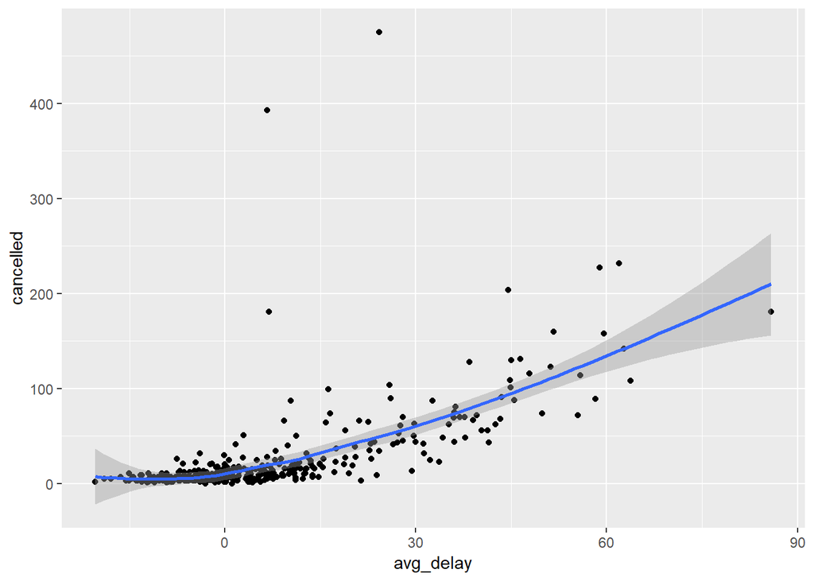

```r
delay_vs_cancelled <- flights %>% group_by(year,month,day) %>% summarise(count=n(),avg_delay=mean(arr_delay,na.rm = TRUE), cancelled=sum(is.na(arr_delay)))
ggplot(delay_vs_cancelled,mapping=aes(x=avg_delay, y=cancelled))+geom_point()+geom_smooth()
```

**Yes number of cancelled flight rises when average delay increases.**

*5.Which carrier has the worst delays? Challenge: can you disentangle the effects of bad airports vs. bad carriers? Why/why not? (Hint: think about flights %>% group_by(carrier, dest) %>% summarise(n()))*

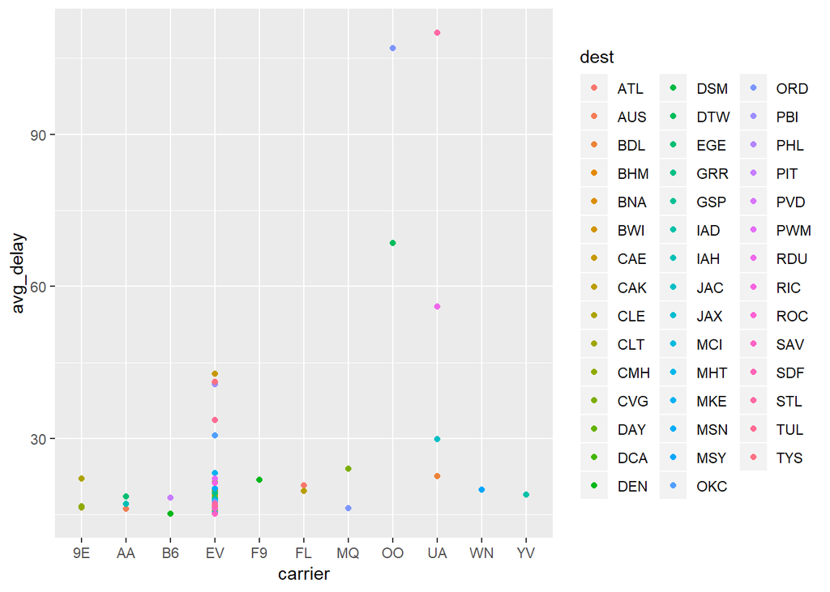

```r
delay_carrier_dest <- flights %>% group_by(carrier, dest) %>% summarise(avg_delay=mean(arr_delay,na.rm=TRUE)) %>% filter(avg_delay > 15)
ggplot(data=delay_carrier_dest)+geom_point(mapping=aes(x=carrier,y=avg_delay,color=dest))
```

**UA and OO experiencing bad delay but only for specific airports. It maybe due to other carrier simply does not go to those airports.**

*6.What does the sort argument to count() do. When might you use it?*

**If sort = TRUE it will sort output in descending order. it will be useful if you want to find out the highest or the lowest count.**

## 10.5 Exercises

*1. How can you tell if an object is a tibble? (Hint: try printing mtcars, which is a regular data frame).*

*2. Compare and contrast the following operations on a data.frame and equivalent tibble. What is different? Why might the default data frame behaviours cause you frustration?*

```r
df <- data.frame(abc = 1, xyz = "a")
df$x
```

```
## [1] a
## Levels: a
```

```r
df[, "xyz"]
```

```
## [1] a
## Levels: a
```

```r
df[, c("abc", "xyz")]
```

```
##   abc xyz
## 1   1   a
```

**no error since data.frame will match string without exact match.**

```r
df <- tibble(abc = 1, xyz = "a")
df$x
```

[output not shown]

```r
df[, "xyz"]
```

```
## # A tibble: 1 x 1
##   xyz
##   <chr>
## 1 a
```

```r
df[, c("abc", "xyz")]
```

```
## # A tibble: 1 x 2
##     abc xyz
##   <dbl> <chr>
## 1     1 a
```

**df$x produce error for tibble since tibble does not do partial match.**

*3. If you have the name of a variable stored in an object, e.g. var <- “mpg”, how can you extract the reference variable from a tibble?*

**need to use [[]] function. tibble[[var]] will extract whatever column name var is having.**

```r
df <- tibble(abc="1", xyz="a")
var <- "abc"
df[[var]]
```

```
## [1] "1"
```

*6.What option controls how many additional column names are printed at the footer of a tibble?*

```r
flights %>% print(n_extra=3)
```

```
## # A tibble: 336,776 x 19
##     year month   day dep_time sched_dep_time dep_delay arr_time
##    <int> <int> <int>    <int>          <int>     <dbl>    <int>
##  1  2013     1     1      517            515         2      830
##  2  2013     1     1      533            529         4      850
##  3  2013     1     1      542            540         2      923
##  4  2013     1     1      544            545        -1     1004
##  5  2013     1     1      554            600        -6      812
##  6  2013     1     1      554            558        -4      740
##  7  2013     1     1      555            600        -5      913
##  8  2013     1     1      557            600        -3      709
##  9  2013     1     1      557            600        -3      838
## 10  2013     1     1      558            600        -2      753
## # ... with 336,766 more rows, and 12 more variables: sched_arr_time <int>,
## #   arr_delay <dbl>, carrier <chr>, ...
```

**using the print function. n_extra specify number of extra columns to print in abbreviated information.**

## 12.3.3 Exercises

*2.Why does this code fail?*

*table4a %>%* *gather(1999, 2000, key = “year”, value = “cases”)* *#> Error in inds_combine(.vars, ind_list): Position must be between 0 and n*

**1999 and 2000 need to be quoted**

*3.Why does spreading this tibble fail? How could you add a new column to fix the problem?*

people <- tribble( ~name, ~key, ~value, #—————–|——–|—— “Phillip Woods”, “age”, 45, “Phillip Woods”, “height”, 186, “Phillip Woods”, “age”, 50, “Jessica Cordero”, “age”, 37, “Jessica Cordero”, “height”, 156 )

**It failed because there can be multiple persons with identical name. I would add a column called index if duplicate name occurs**

```r
people <- tribble(
  ~name,     ~index,        ~key,    ~value,
  #-----------------|---|--------|------
  "Phillip Woods",   1,  "age",       45,
  "Phillip Woods",   1,  "height",   186,
  "Phillip Woods",   2,  "age",       50,
  "Jessica Cordero", 1,  "age",       37,
  "Jessica Cordero", 1,  "height",   156
)
people %>% spread(key=key, value=value)
```

```
## # A tibble: 3 x 4
##   name            index   age height
##   <chr>           <dbl> <dbl>  <dbl>
## 1 Jessica Cordero     1    37    156
## 2 Phillip Woods       1    45    186
## 3 Phillip Woods       2    50     NA
```

*4.Tidy the simple tibble below. Do you need to spread or gather it? What are the variables?*

preg <- tribble( ~pregnant, ~male, ~female, “yes”, NA, 10, “no”, 20, 12 )

**Need gather to tidy the tibble. The variables are pregnant, gender, and count**

```r
preg <- tribble(
  ~pregnant, ~male, ~female,
  "yes",     NA,    10,
  "no",      20,    12
)
gather(preg,"male","female",k="gender", value = "count")
```

```
## # A tibble: 4 x 3
##   pregnant gender count
##   <chr>    <chr>  <dbl>
## 1 yes      male      NA
## 2 no       male      20
## 3 yes      female    10
## 4 no       female    12
```

## 12.4.3 Exercises

*1.What do the extra and fill arguments do in separate()? Experiment with the various options for the following two toy datasets.*

```r
tibble(x = c("a,b,c", "d,e,f,g", "h,i,j")) %>%
  separate(x, c("one", "two", "three"))
```

```
## # A tibble: 3 x 3
##   one   two   three
##   <chr> <chr> <chr>
## 1 a     b     c
## 2 d     e     f
## 3 h     i     j
```

```r
tibble(x = c("a,b,c", "d,e", "f,g,i")) %>%
  separate(x, c("one", "two", "three"))
```

```
## # A tibble: 3 x 3
##   one   two   three
##   <chr> <chr> <chr>
## 1 a     b     c
## 2 d     e     <NA>
## 3 f     g     i
```

```r
   tibble(x = c("a,b,c", "d,e,f,g", "h,i,j")) %>% separate(x, c("one", "two", "three"),extra="merge")
```

```
## # A tibble: 3 x 3
##   one   two   three
##   <chr> <chr> <chr>
## 1 a     b     c
## 2 d     e     f,g
## 3 h     i     j
```

```r
  tibble(x = c("a,b,c", "d,e,f,g", "h,i,j")) %>% separate(x, c("one", "two", "three"),extra="drop")
```

```
## # A tibble: 3 x 3
##   one   two   three
##   <chr> <chr> <chr>
## 1 a     b     c
## 2 d     e     f
## 3 h     i     j
```

```r
  tibble(x = c("a,b,c", "d,e,f,g", "h,i,j")) %>% separate(x, c("one", "two", "three"),extra="warn")
```

```
## # A tibble: 3 x 3
##   one   two   three
##   <chr> <chr> <chr>
## 1 a     b     c
## 2 d     e     f
## 3 h     i     j
```

```r
  tibble(x = c("a,b,c", "d,e", "f,g,i")) %>%
  separate(x, c("one", "two", "three"))
```

```
## # A tibble: 3 x 3
##   one   two   three
##   <chr> <chr> <chr>
## 1 a     b     c
## 2 d     e     <NA>
## 3 f     g     i
```

```r
  tibble(x = c("a,b,c", "d,e", "f,g,i")) %>%
  separate(x, c("one", "two", "three"),drop=right)
```

```
## # A tibble: 3 x 3
##   one   two   three
##   <chr> <chr> <chr>
## 1 a     b     c
## 2 d     e     <NA>
## 3 f     g     i
```

```r
  tibble(x = c("a,b,c", "d,e", "f,g,i")) %>%
  separate(x, c("one", "two", "three"),drop=left)
```

```
## # A tibble: 3 x 3
##   one   two   three
##   <chr> <chr> <chr>
## 1 a     b     c
## 2 d     e     <NA>
## 3 f     g     i
```

**extra and fill perform as what they literally means.**

*2.Both unite() and separate() have a remove argument. What does it do? Why would you set it to FALSE?*

**The default for remove is TRUE, which removes original column separated or united from output. you set it to FALSE if you want to keep the original column in output for comparison or varification.**

## Follow these steps:

*- Download the baby_names.txt file from Canvas which is in the Homework 4 assignment section.* *- Load this file into R correctly and take a glimpse of the output.* *- Export this file as a csv file and call it ‘baby_names.csv’.* *- Reload the baby_names.csv file and take another glimpse.* *- Show all of your code and the output. There should be two data import lines of code, one data export line of code, and two glimpses of the data.*

```r
file_path <- 'c:/users/chisun/downloads/baby_names.txt'
csv_data <- read_delim(file_path, delim = "|" )
csv_data
```

```
## # A tibble: 30,000 x 5
##     year sex   name          n   prop
##    <dbl> <chr> <chr>     <dbl>  <dbl>
##  1  1880 F     Mary       7065 0.0724
##  2  1880 F     Anna       2604 0.0267
##  3  1880 F     Emma       2003 0.0205
##  4  1880 F     Elizabeth  1939 0.0199
##  5  1880 F     Minnie     1746 0.0179
##  6  1880 F     Margaret   1578 0.0162
##  7  1880 F     Ida        1472 0.0151
##  8  1880 F     Alice      1414 0.0145
##  9  1880 F     Bertha     1320 0.0135
## 10  1880 F     Sarah      1288 0.0132
## # ... with 29,990 more rows
```

```r
out_file_path <- "C:/users/chisun/downloads/baby_names.csv"
write_csv(csv_data,out_file_path)
new_csv_data=read_csv(out_file_path)
new_csv_data
```

```
## # A tibble: 30,000 x 5
##     year sex   name          n   prop
##    <dbl> <chr> <chr>     <dbl>  <dbl>
##  1  1880 F     Mary       7065 0.0724
##  2  1880 F     Anna       2604 0.0267
##  3  1880 F     Emma       2003 0.0205
##  4  1880 F     Elizabeth  1939 0.0199
##  5  1880 F     Minnie     1746 0.0179
##  6  1880 F     Margaret   1578 0.0162
##  7  1880 F     Ida        1472 0.0151
##  8  1880 F     Alice      1414 0.0145
##  9  1880 F     Bertha     1320 0.0135
## 10  1880 F     Sarah      1288 0.0132
## # ... with 29,990 more rows
```